# **Predicting Churn for Bank Cusomers**

**Os dados foram obtidos daqui:**[Predicting Churn for Bank Customers](https://www.kaggle.com/datasets/adammaus/predicting-churn-for-bank-customers)

[figure not shown]

# Índice

## **Problema**

Saber por que um cliente abandona ou deixa de comprar seu produto é fundamental para garantir um crescimento sustentável a longo prazo, além disso é muito menos custoso para a empresa reter um cliente do que prospectar novos. Os departamentos de marketing, vendas e retenção precisam garantir a satisfação dos clientes, fornecer incentivos e apresentar ofertas no momento certo para reduzir a rotatividade. Esse projeto de Machine Learning visa ajudar as equipes de marketing, vendas e retenção de clientes a determinar o momento certo para fazer uma oferta e assim minimizar o abandono dos clientes.

### Alguns motivos importantes para evitar o churn:

- É mais caro prospectar novos cliente do que mantê-los.
- Caso o cliente saia da instituição, a chance de retorno é muito pequena.
- Clientes que deixam a instituição não costumam recomendá-la.

## **Sobre os Dados**

### O conjunto de dados é composto pelas seguintes variáveis:

- **RowNumber**:número de linhas.
- **CustomerId**: número de identificação.
- **Surname**: Sobrenome.
- **CreditScore**:A classificação do cliente no Banco.
- **Geography**:País.
- **Gender**:Sexo.
- **Age**:Idade.
- **Tenure**:Tempo de permanência.
- **Balance**:Saldo em conta.
- **NumOfProducts**:Quantidade de produtos que o cliente possui com o banco.
- **HasCrCard**:Cliente possui cartão de crédito? "0 = Não Possui" e "1 = Possui".
- **IsActiveMember**:Cliente é membro ativo? "0 = Não" e "1 = Sim".
- **EstimatedSalary**:Salário estimado.
- **Exited**:Saiu? "0 = Não" e "1 = Sim".

### Algumas dúvidas e problemas que surgiram sobre a base de dados:

- Não temos data e, portanto, não tempos uma informação mais sucinta sobre o Saldo (Balance), pois o cliente pode receber seu salário em um dia e remove da conta em outro, não sabemos também a origem do Saldo se é todo o capital, saldo em CC, aplicações etc.
- Qual o significado de membro ativo? Um cliente que não movimentou por x período? Não há como mensurar.

## **Limpeza e Pré-processamento**

```python
#importando as libs para a análise.
import pandas as pd
import numpy as np
import matplotlib.pyplot as plt
import seaborn as sns
import plotly.express as px
import warnings
warnings.filterwarnings("ignore")
import missingno as missing
pd.set_option('display.float_format', lambda x: '%.3f' % x)
```

```python
# Carregando os dados
df = pd.read_csv('./data/Churn_Modelling.csv')
```

```python
# as 5 primeiras linhas.
df.head()
```

|  | RowNumber | CustomerId | Surname | CreditScore | Geography | Gender | Age | Tenure | Balance | NumOfProducts | HasCrCard | IsActiveMember | EstimatedSalary | Exited |
| --- | --- | --- | --- | --- | --- | --- | --- | --- | --- | --- | --- | --- | --- | --- |
| 0 | 1 | 15634602 | Hargrave | 619 | France | Female | 42 | 2 | 0.000 | 1 | 1 | 1 | 101348.880 | 1 |
| 1 | 2 | 15647311 | Hill | 608 | Spain | Female | 41 | 1 | 83807.860 | 1 | 0 | 1 | 112542.580 | 0 |
| 2 | 3 | 15619304 | Onio | 502 | France | Female | 42 | 8 | 159660.800 | 3 | 1 | 0 | 113931.570 | 1 |
| 3 | 4 | 15701354 | Boni | 699 | France | Female | 39 | 1 | 0.000 | 2 | 0 | 0 | 93826.630 | 0 |
| 4 | 5 | 15737888 | Mitchell | 850 | Spain | Female | 43 | 2 | 125510.820 | 1 | 1 | 1 | 79084.100 | 0 |

```python
# Exibindo os valores que são únicos de cada feature.
print("Valores únicos (por coluna):\n{}\n".format(df.nunique()))
```

```
Valores únicos (por coluna):
RowNumber          10000
CustomerId         10000
Surname             2932
CreditScore          460
Geography              3
Gender                 2
Age                   70
Tenure                11
Balance             6382
NumOfProducts          4
HasCrCard              2
IsActiveMember         2
EstimatedSalary     9999
Exited                 2
dtype: int64
```

### Transformação e Manipulação

- **Alterando os tipos de dados para reduzir o uso de recursos computacionais.**

```python
# informação do tipo, tamnanho e dados nulos.
df.info()
```

```
<class 'pandas.core.frame.DataFrame'>
RangeIndex: 10000 entries, 0 to 9999
Data columns (total 14 columns):
 #   Column           Non-Null Count  Dtype
---  ------           --------------  -----
 0   RowNumber        10000 non-null  int64
 1   CustomerId       10000 non-null  int64
 2   Surname          10000 non-null  object
 3   CreditScore      10000 non-null  int64
 4   Geography        10000 non-null  object
 5   Gender           10000 non-null  object
 6   Age              10000 non-null  int64
 7   Tenure           10000 non-null  int64
 8   Balance          10000 non-null  float64
 9   NumOfProducts    10000 non-null  int64
 10  HasCrCard        10000 non-null  int64
 11  IsActiveMember   10000 non-null  int64
 12  EstimatedSalary  10000 non-null  float64
 13  Exited           10000 non-null  int64
dtypes: float64(2), int64(9), object(3)
memory usage: 1.1+ MB
```

```python
#Convertendo os dados tipo categóricos
df['Geography'] = df['Geography'].astype('category')
df['Gender'] = df['Gender'].astype('category')
df['HasCrCard'] = df['HasCrCard'].astype('category')
df['IsActiveMember'] = df['IsActiveMember'].astype('category')
#exceção para o dado categórico Exited que será convertido em int64
df['Exited'] = df['Exited'].astype('int64')
```

```python
df.info()
```

```
<class 'pandas.core.frame.DataFrame'>
RangeIndex: 10000 entries, 0 to 9999
Data columns (total 14 columns):
 #   Column           Non-Null Count  Dtype
---  ------           --------------  -----
 0   RowNumber        10000 non-null  int64
 1   CustomerId       10000 non-null  int64
 2   Surname          10000 non-null  object
 3   CreditScore      10000 non-null  int64
 4   Geography        10000 non-null  category
 5   Gender           10000 non-null  category
 6   Age              10000 non-null  int64
 7   Tenure           10000 non-null  int64
 8   Balance          10000 non-null  float64
 9   NumOfProducts    10000 non-null  int64
 10  HasCrCard        10000 non-null  category
 11  IsActiveMember   10000 non-null  category
 12  EstimatedSalary  10000 non-null  float64
 13  Exited           10000 non-null  int64
dtypes: category(4), float64(2), int64(7), object(1)
memory usage: 820.9+ KB
```

- **Conseguimos reduzir o tamanho dos dados de 1.1Mb para 820KB.**
- **Vamos reduzir ainda mais ao remover as colunas RowNumber, CustomerId e Surname que aparentemente não são relevantes.**

### Limpeza dos Dados

```python
#Descarte de variáveis que aparentemente não são importantes
df.drop(['RowNumber', 'CustomerId', 'Surname'], axis = 1, inplace = True)
df.info()
```

```
<class 'pandas.core.frame.DataFrame'>
RangeIndex: 10000 entries, 0 to 9999
Data columns (total 11 columns):
 #   Column           Non-Null Count  Dtype
---  ------           --------------  -----
 0   CreditScore      10000 non-null  int64
 1   Geography        10000 non-null  category
 2   Gender           10000 non-null  category
 3   Age              10000 non-null  int64
 4   Tenure           10000 non-null  int64
 5   Balance          10000 non-null  float64
 6   NumOfProducts    10000 non-null  int64
 7   HasCrCard        10000 non-null  category
 8   IsActiveMember   10000 non-null  category
 9   EstimatedSalary  10000 non-null  float64
 10  Exited           10000 non-null  int64
dtypes: category(4), float64(2), int64(5)
memory usage: 586.6 KB
```

- **Parece pouco, mas imaginem em um ambiente de produção com uma base na casa dos Terabytes, reduzir o tamanho do conjunto pela metade, certamente trará muitos benefícios, como redução de recursos computacionais e velocidade no processamento.**
- **Agora podemos seguir a análise.**

### Registros missing

```
CreditScore        0
Geography          0
Gender             0
Age                0
Tenure             0
Balance            0
NumOfProducts      0
HasCrCard          0
IsActiveMember     0
EstimatedSalary    0
Exited             0
dtype: int64
```

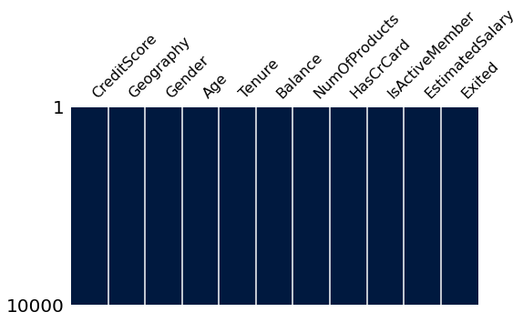

```python
# Conferindo se existem dados faltantes.
missing.matrix(df, figsize = (8, 4), color = (0, 0.1, 0.25), sparkline = False);
df.isnull().sum()
```

### Verificar distribuições das variáveis e possíveis transformações

- **Qual a proporção de Churn?**

```python
# configurando parâmetros das fontes
plt.rcParams['font.family'] = 'sans-serif'
# definindo cores do gráfico em sistema hexadecimal
CINZA1, CINZA2= "#CFCDCE", "#A2A1A3"
AZUL1, AZUL2 = "#8db7eb", "#253760"
```

```python
# valors e labels para o gráfico.
lista = (df.Exited.value_counts()/df.shape[0] * 100).round(2)
labels = ['Normal','Churn']
x = np.arange(len(labels))
```

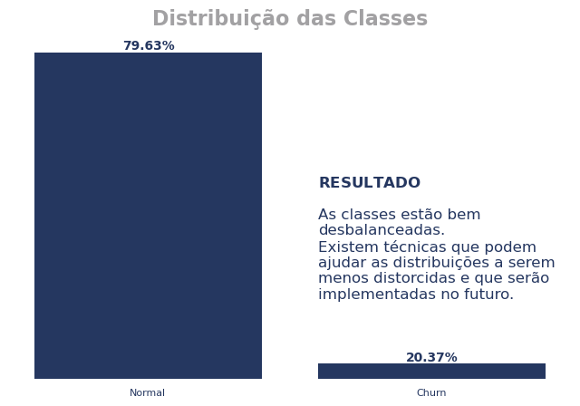

```python
# criando uma figura para grafico de barras
fig, ax = plt.subplots(figsize=(8, 5))
rects1 = ax.bar(x, lista,color=AZUL2,log=True)
ax.set_title('Distribuição das Classes',
             fontsize=16, color=CINZA2,
             verticalalignment='bottom',
             weight='bold')
ax.set_xticks(x)
ax.set_xticklabels(labels,color=AZUL2)
# removendo grids e eixos (linhas)
ax.spines['right'].set_visible(False)
ax.spines['left'].set_visible(False)
ax.spines['top'].set_visible(False)
ax.spines['bottom'].set_visible(False)
# removendo eixo y
plt.gca().axes.get_yaxis().set_visible(False)
# removendo xticks do eixo x
plt.tick_params(
    axis='both',
    which='both',
    bottom=False,
    top=False,
    labelbottom=True)
def autolabel(rects):
    for rect in rects:
        height = rect.get_height()
        ax.annotate(
                    '{}%'.format(height),
                    xy=(rect.get_x() + rect.get_width(),  height),
                    xytext=(-90, 0),  # offset
                    textcoords="offset points",
                    ha='center',
                    va='bottom',
                    fontsize=10,
                    color=AZUL2,
                    weight='bold'
                    )

# plotando anotações do resultado da análise
plt.text(0.6, 25,
         "$\\bf{RESULTADO}$\n\n"
         "As classes estão bem\n"
         "desbalanceadas.\n"
         "Existem técnicas que podem\n"
         "ajudar as distribuições a serem\n"
         "menos distorcidas e que serão\n"
         "implementadas no futuro.\n"
         ,
         verticalalignment="bottom",
         fontsize=12,
         color=AZUL2)

# plotando labels acima das barras com a função
autolabel(rects1)
# salvando o gráfico
plt.savefig('bar_orig_churn.png',format='png')
plt.plot();
```

- **Muitos clientes não possuem saldo em conta, será que utilizam somente cartão de crédido?**

```python
#porcentagem de clientes sem saldo que possuem cartão de crédito
df_bal_0 = df.query('Balance == 0')
(df_bal_0['HasCrCard'].value_counts() / len(df_bal_0) * 100).round(2)
```

```
1   71.660
0   28.340
Name: HasCrCard, dtype: float64
```

- **Confirmado, cerca de 72% dos clientes que não possuem saldo em conta, possuem cartão de crédito.**
- **Qual a porcentagem de churn desses clientes?**

```python
#porcentagem de clientes sem saldo em conta que deram Churn.
(df_bal_0['Exited'].value_counts() / len(df_bal_0) * 100).round(2)
```

```
0   86.180
1   13.820
Name: Exited, dtype: float64
```

- **De todos os clientes que não possuem saldo, obtivemos uma taxa aproximada de 14% de Churn. Inferior aos 20% da base toda.**
- **Qual a porcentagem de Churn para os clientes que possuem algum saldo em conta?**

```python
df_bal_1 = df.query('Balance > 0')
(df_bal_1['Exited'].value_counts() / len(df_bal_1) * 100).round(2)
```

```
0   75.920
1   24.080
Name: Exited, dtype: float64
```

- **Clientes que possuem algum saldo em conta, possuem uma propensão aproximada de 24% de Churn.**

## Análise Exploratória

### EDA com Sweetviz

```python
#Analise exploratória com Sweetviz
import sweetviz as sv
eda = sv.analyze(source = df, target_feat = 'Exited')
eda.show_notebook()
```

```
                                             |                                             | [  0%]   00:00 ->…
```

[interactive chart not shown]

### Estatística Descritiva

```python
#Descrição dos clientes que não possuem saldo em conta.
df_bal_0.describe()
```

|  | CreditScore | Age | Tenure | Balance | NumOfProducts | EstimatedSalary | Exited |
| --- | --- | --- | --- | --- | --- | --- | --- |
| count | 3617.000 | 3617.000 | 3617.000 | 3617.000 | 3617.000 | 3617.000 | 3617.000 |
| mean | 649.453 | 38.435 | 5.071 | 0.000 | 1.785 | 98983.560 | 0.138 |
| std | 96.159 | 10.492 | 2.861 | 0.000 | 0.496 | 57730.829 | 0.345 |
| min | 350.000 | 18.000 | 0.000 | 0.000 | 1.000 | 90.070 | 0.000 |
| 25% | 583.000 | 31.000 | 3.000 | 0.000 | 1.000 | 49506.820 | 0.000 |
| 50% | 651.000 | 37.000 | 5.000 | 0.000 | 2.000 | 98618.790 | 0.000 |
| 75% | 717.000 | 43.000 | 7.000 | 0.000 | 2.000 | 148330.970 | 0.000 |
| max | 850.000 | 88.000 | 10.000 | 0.000 | 4.000 | 199992.480 | 1.000 |

```python
#Descrição dos clientes que possuem saldo em conta.
df_bal_1.describe()
```

|  | CreditScore | Age | Tenure | Balance | NumOfProducts | EstimatedSalary | Exited |
| --- | --- | --- | --- | --- | --- | --- | --- |
| count | 6383.000 | 6383.000 | 6383.000 | 6383.000 | 6383.000 | 6383.000 | 6383.000 |
| mean | 651.138 | 39.198 | 4.980 | 119827.494 | 1.386 | 100717.353 | 0.241 |
| std | 96.935 | 10.476 | 2.910 | 30095.056 | 0.577 | 57380.317 | 0.428 |
| min | 350.000 | 18.000 | 0.000 | 3768.690 | 1.000 | 11.580 | 0.000 |
| 25% | 584.000 | 32.000 | 2.000 | 100181.975 | 1.000 | 51736.850 | 0.000 |
| 50% | 652.000 | 38.000 | 5.000 | 119839.690 | 1.000 | 101139.300 | 0.000 |
| 75% | 718.000 | 44.000 | 8.000 | 139512.290 | 2.000 | 149596.615 | 0.000 |
| max | 850.000 | 92.000 | 10.000 | 250898.090 | 4.000 | 199970.740 | 1.000 |

```python
df.head()
```

|  | CreditScore | Geography | Gender | Age | Tenure | Balance | NumOfProducts | HasCrCard | IsActiveMember | EstimatedSalary | Exited |
| --- | --- | --- | --- | --- | --- | --- | --- | --- | --- | --- | --- |
| 0 | 619 | France | Female | 42 | 2 | 0.000 | 1 | 1 | 1 | 101348.880 | 1 |
| 1 | 608 | Spain | Female | 41 | 1 | 83807.860 | 1 | 0 | 1 | 112542.580 | 0 |
| 2 | 502 | France | Female | 42 | 8 | 159660.800 | 3 | 1 | 0 | 113931.570 | 1 |
| 3 | 699 | France | Female | 39 | 1 | 0.000 | 2 | 0 | 0 | 93826.630 | 0 |
| 4 | 850 | Spain | Female | 43 | 2 | 125510.820 | 1 | 1 | 1 | 79084.100 | 0 |

```python
#Apenas para um melhor entendimento, será realizada a transformação dos booleanos
df["HasCrCard"] = df["HasCrCard"].map({ 0 : 'Não', 1 : 'Sim'})
df["IsActiveMember"] = df["IsActiveMember"].map({ 0 : 'Não', 1 : 'Sim'})
df["Exited"] = df["Exited"].map({ 0 : 'Não', 1 : 'Sim'})
```

```python
#porcentagem de clientes por país.
round(df['Geography'].value_counts(normalize=True),2)
```

```
France    0.500
Germany   0.250
Spain     0.250
Name: Geography, dtype: float64
```

```python
#Porcentagem por sexo.
df['Gender'].value_counts(normalize=True).round(2)
```

```
Male     0.550
Female   0.450
Name: Gender, dtype: float64
```

```python
#Porcentagem de clientes que possuem/Não possuem cartão de crédito.
df['HasCrCard'].value_counts(normalize=True).round(2)
```

```
Sim   0.710
Não   0.290
Name: HasCrCard, dtype: float64
```

```python
#Porcentagem de clientes ativos/não ativos.
df['IsActiveMember'].value_counts(normalize=True).round(2)
```

```
Sim   0.520
Não   0.480
Name: IsActiveMember, dtype: float64
```

```python
#informações descritivas.
df.describe().round(2).T
```

|  | count | mean | std | min | 25% | 50% | 75% | max |
| --- | --- | --- | --- | --- | --- | --- | --- | --- |
| CreditScore | 10000.000 | 650.530 | 96.650 | 350.000 | 584.000 | 652.000 | 718.000 | 850.000 |
| Age | 10000.000 | 38.920 | 10.490 | 18.000 | 32.000 | 37.000 | 44.000 | 92.000 |
| Tenure | 10000.000 | 5.010 | 2.890 | 0.000 | 3.000 | 5.000 | 7.000 | 10.000 |
| Balance | 10000.000 | 76485.890 | 62397.410 | 0.000 | 0.000 | 97198.540 | 127644.240 | 250898.090 |
| NumOfProducts | 10000.000 | 1.530 | 0.580 | 1.000 | 1.000 | 1.000 | 2.000 | 4.000 |
| EstimatedSalary | 10000.000 | 100090.240 | 57510.490 | 11.580 | 51002.110 | 100193.920 | 149388.250 | 199992.480 |

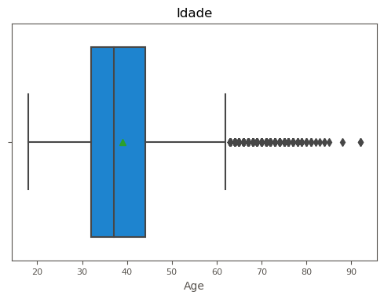

```python
# boxplot com indicador da média para comparação com a mediana e visualização dos outliers.
sns.boxplot(df['Age'], showmeans=True).set_title('Idade');
```

### Será que estamos perdendo mais clientes de algum País em específico?

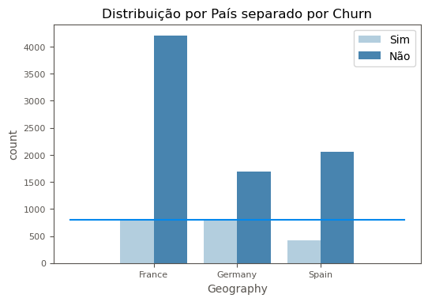

```python
sns.countplot(df['Geography'], hue=df.Exited, palette='Blues').set_title('Distribuição por País separado por Churn')
sns.lineplot(x=[-1,0,1,2,3] ,y=800)
```

### Será que a idade pode influenciar na perda de clientes?

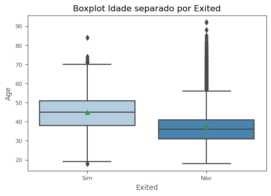

```python
sns.boxplot(data=df, x="Exited", y="Age", showmeans=True,palette='Blues').set_title('Boxplot Idade separado por Exited');
```

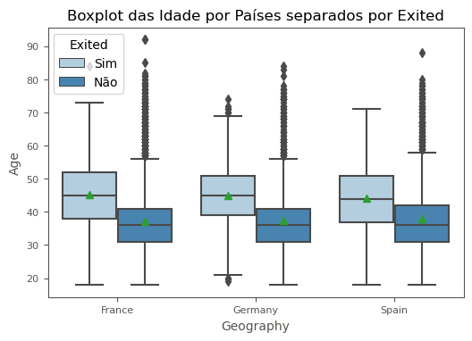

```python
sns.boxplot(x="Geography", y="Age", hue="Exited", showmeans=True, data=df, palette='Blues').set_title('Boxplot das Idade por Países separados por Exited');
```

```python
va_correlacao = df[['CreditScore','Age','Balance','EstimatedSalary','Exited']]
va_correlacao.corr()
```

|  | CreditScore | Age | Balance | EstimatedSalary |
| --- | --- | --- | --- | --- |
| CreditScore | 1.000 | -0.004 | 0.006 | -0.001 |
| Age | -0.004 | 1.000 | 0.028 | -0.007 |
| Balance | 0.006 | 0.028 | 1.000 | 0.013 |
| EstimatedSalary | -0.001 | -0.007 | 0.013 | 1.000 |

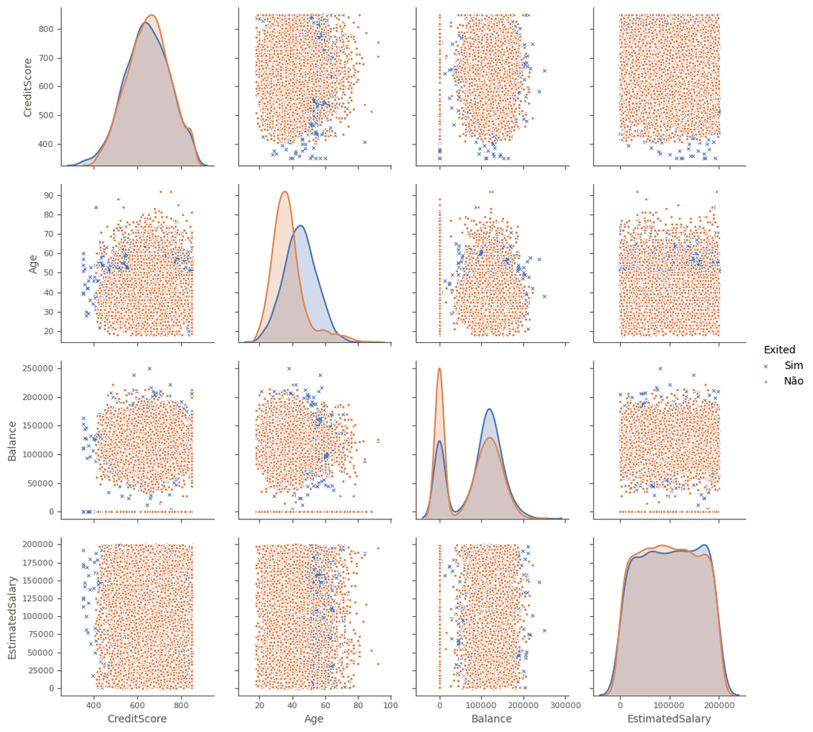

```python
sns.pairplot(data=va_correlacao, hue="Exited",palette='deep', markers=['x','o']);
```

```python
#Porcentagens de Churn dos clientes com saldo em conta, e com idade maior ou igual a 43 anos.
df.query('Balance > 0 and Age >= 43')['Exited'].value_counts(normalize=True)
```

```
Não   0.531
Sim   0.469
Name: Exited, dtype: float64
```

```python
#Porcentagem de clientes com saldo igual a 0 e idade menor do que 43 anos separados por Churn.
df.query('Balance == 0 and Age < 43')['Exited'].value_counts(normalize=True)
```

```
Não   0.923
Sim   0.077
Name: Exited, dtype: float64
```

```python
#quantidade de clientes separados por Churn.
df['Exited'].value_counts()
```

```
Não    7963
Sim    2037
Name: Exited, dtype: int64
```

### Distribuição das classes

```python
#convertendo novamente para o tipo inteiro
df["Exited"] = df["Exited"].map({ 'Não':0, 'Sim':1}).astype('int64')
```

```python
#Função para tirar a média de churn pela variável em questão e plotar um grafico de distribuição com a média e uma projeção de 10%.
def media_by_churn(list_col, var_churn):
    pd.set_option('display.max_rows', None)
    for i in list_col:
        media = df[[i,var_churn]].groupby([i]).mean().round(2).reset_index()
        print(f'Media de Churn por {i}:\n')
        print(media,'\n')
        print('--'*15)
        #Plotando um gráfico para visualizar a distribuição de churn por idade.
        plt.figure(figsize=(12,4))
        plt.axhline(media[var_churn].mean()+.1,0,1)
        plt.axhline(media[var_churn].mean(),0,1,color='r',**{'ls':'--'})
        ax = sns.barplot(x= i,y=var_churn,data=media, palette='ocean_r')
        plt.xticks(rotation=45)
        plt.title(f'Distribuição de Churn por {i}')
        plt.show()
        print('**'*20)

    pd.set_option('display.max_rows', 10)
```

```python
#lista das colunas para comparar as médias de churn
colunas = ['Geography', 'Gender', 'Age', 'Tenure','NumOfProducts', 'HasCrCard', 'IsActiveMember']
#Variável Churn
churn = 'Exited'
```

```
Media de Churn por Geography:

  Geography  Exited
0    France   0.160
1   Germany   0.320
2     Spain   0.170

------------------------------
```

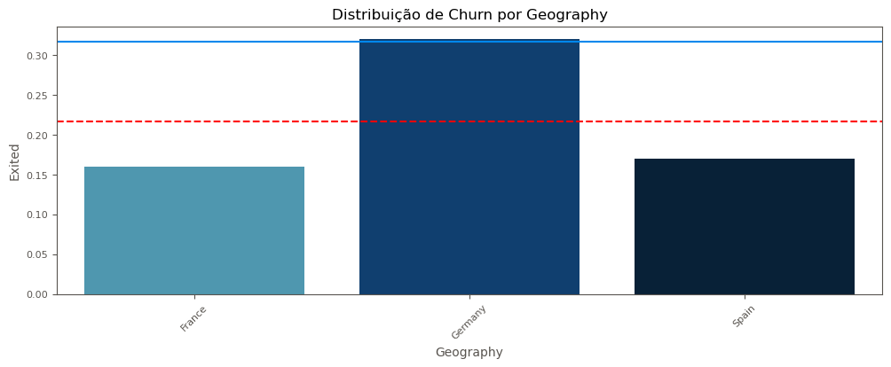

```
Media de Churn por Gender:

   Gender  Exited
0  Female   0.250
1    Male   0.160

------------------------------
```

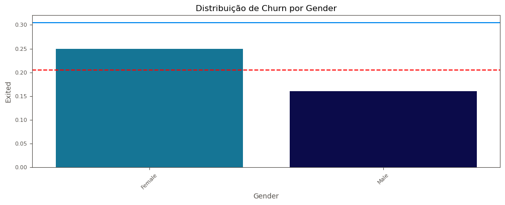

```
Media de Churn por Age:

    Age  Exited
0    18   0.090
1    19   0.040
2    20   0.050
3    21   0.060
4    22   0.140
5    23   0.060
6    24   0.110
7    25   0.040
8    26   0.070
9    27   0.060
10   28   0.080
11   29   0.080
```

[output cut: 60 more lines]

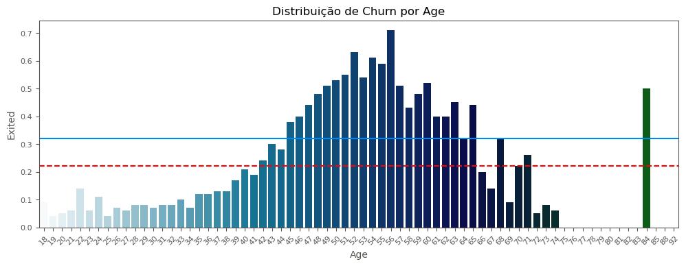

```
Media de Churn por Tenure:

    Tenure  Exited
0        0   0.230
1        1   0.220
2        2   0.190
3        3   0.210
4        4   0.210
5        5   0.210
6        6   0.200
7        7   0.170
8        8   0.190
9        9   0.220
10      10   0.210

------------------------------
```

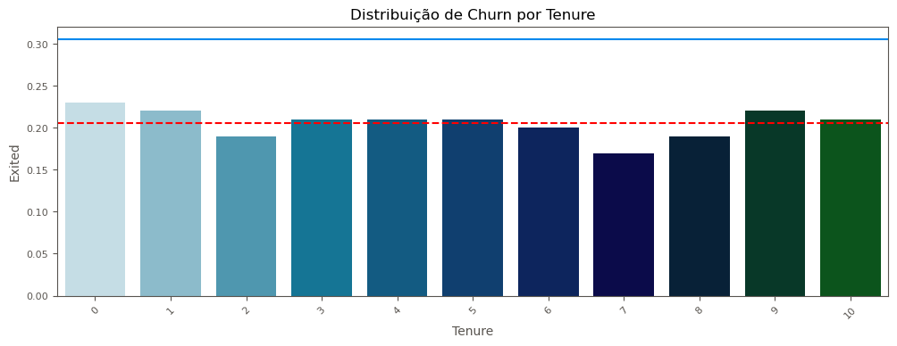

```
Media de Churn por NumOfProducts:

   NumOfProducts  Exited
0              1   0.280
1              2   0.080
2              3   0.830
3              4   1.000

------------------------------
```

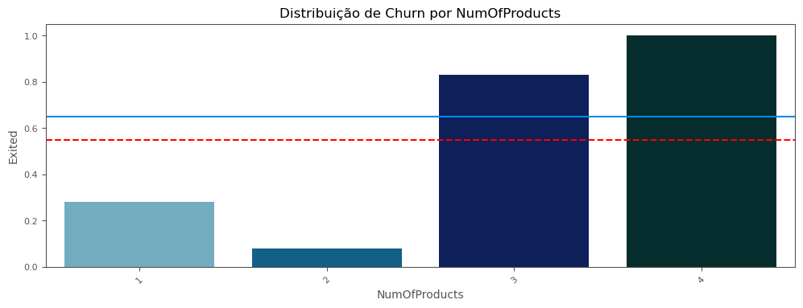

```
Media de Churn por HasCrCard:

  HasCrCard  Exited
0       Não   0.210
1       Sim   0.200

------------------------------
```

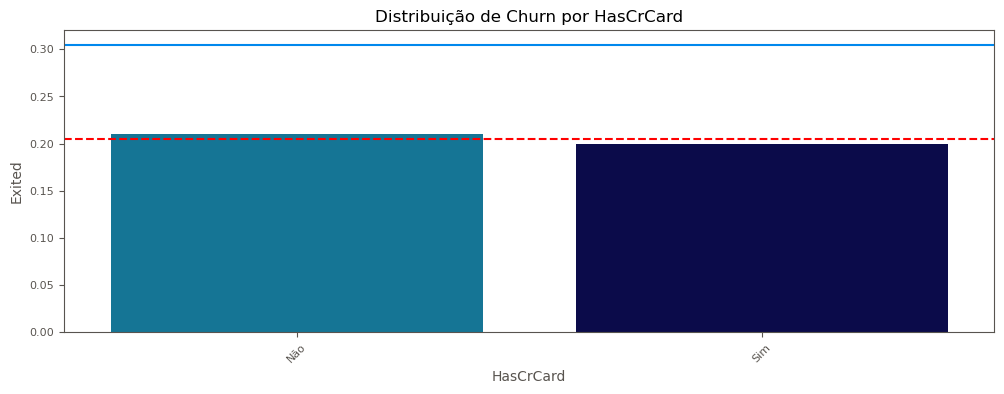

```
Media de Churn por IsActiveMember:

  IsActiveMember  Exited
0            Não   0.270
1            Sim   0.140

------------------------------
```

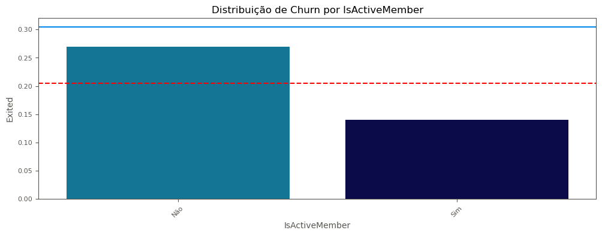

```python
#Verificando a média de churn das variáveis selecionadas.
media_by_churn(colunas,churn)
```

## Entendimento do Negócio

```python
# quantos clientes saíram e quantos ficaram.
df.Exited.value_counts()
```

```
0    7963
1    2037
Name: Exited, dtype: int64
```

```python
#quantos clientes saíram e quantos ficaram do banco - Germany
df.query('Geography == "Germany"')['Exited'].value_counts()
```

```
0    1695
1     814
Name: Exited, dtype: int64
```

- **Cerca de 40% de todo Churn estão concentrados na Alemanha - se encerrassemos as atividades na Alemanha quanto reduziriamos de churn?**
- **R. Reduziriamos o Churn total em 4%**

```python
#quantos clientes saíram e quantos ficaram dos bancos Spanha e França
df.query('Geography != "Germany"')['Exited'].value_counts(normalize=True)
```

```
0   0.837
1   0.163
Name: Exited, dtype: float64
```

- **Dos clientes que sairam, qual a soma que eles tinham em valores?**

```python
#Soma total de balance dos que sairam.
df.query('Exited == 1')['Balance'].sum()
```

```
185588094.63
```

**185.588.094,63 Euros**

```python
# Soma total de balance dos que ficaram.
df.query('Exited == 0')['Balance'].sum()
```

```
579270798.25
```

**579.270.798,25 Euros**

```python
(185588094.63 / 579270798.25) * 100
```

```
32.03822723166246
```

```python
df.query('Exited == 0')[['Balance','EstimatedSalary']].describe()
```

|  | Balance | EstimatedSalary |
| --- | --- | --- |
| count | 7963.000 | 7963.000 |
| mean | 72745.297 | 99738.392 |
| std | 62848.041 | 57405.587 |
| min | 0.000 | 90.070 |
| 25% | 0.000 | 50783.490 |
| 50% | 92072.680 | 99645.040 |
| 75% | 126410.280 | 148609.955 |
| max | 221532.800 | 199992.480 |

```python
df.query('Exited == 1')[['Balance','EstimatedSalary']].describe()
```

|  | Balance | EstimatedSalary |
| --- | --- | --- |
| count | 2037.000 | 2037.000 |
| mean | 91108.539 | 101465.678 |
| std | 58360.795 | 57912.418 |
| min | 0.000 | 11.580 |
| 25% | 38340.020 | 51907.720 |
| 50% | 109349.290 | 102460.840 |
| 75% | 131433.330 | 152422.910 |
| max | 250898.090 | 199808.100 |

- **Tanto para Balance quanto para EstimatedSalary os valores são maiores para os clientes que deram churn se compararmos com a média e mediana.**

```python
df.query('Exited == 1 & Balance == 0')['EstimatedSalary'].describe()
```

```
count      500.000
mean    101782.089
std      58029.832
min        417.410
25%      52701.152
50%     100881.125
75%     151778.443
max     199290.680
Name: EstimatedSalary, dtype: float64
```

```python
df.query('Exited == 1 & Balance > 0')['EstimatedSalary'].describe()
```

```
count     1537.000
mean    101362.746
std      57892.711
min         11.580
25%      51548.140
50%     102566.460
75%     152450.840
max     199808.100
Name: EstimatedSalary, dtype: float64
```

- **Apesar de muitos clientes não possuirem direinho em caixa, a média e mediana continua próxima se comparado com os que deram Churn e possuem algum valor.**

```python
df.query('Exited == 1 & Balance == 0')['IsActiveMember'].value_counts()
```

```
Não    320
Sim    180
Name: IsActiveMember, dtype: int64
```

```python
df.columns
```

```
Index(['CreditScore', 'Geography', 'Gender', 'Age', 'Tenure', 'Balance',
       'NumOfProducts', 'HasCrCard', 'IsActiveMember', 'EstimatedSalary',
       'Exited'],
      dtype='object')
```

```python
df.query('Exited == 1 & Balance == 0 & IsActiveMember =="Não"')['HasCrCard'].value_counts()
```

```
Sim    235
Não     85
Name: HasCrCard, dtype: int64
```

```python
df.query('Exited == 1 & Balance == 0 & IsActiveMember =="Não"')['NumOfProducts'].value_counts()
```

```
1    223
2     55
3     36
4      6
Name: NumOfProducts, dtype: int64
```

```python
df.query('Exited == 1 & Balance == 0 & IsActiveMember =="Não"')['Geography'].value_counts()
```

```
France     209
Spain      111
Germany      0
Name: Geography, dtype: int64
```

- **320 clientes que deram Churn, eram clientes que não tinham Saldo em conta e não eram membros ativos**
- **Desses clientes a 235 tinham cartão de crédito e 223 tinham apenas um produto (cartão de crédito) possivelmente.**
- **85 não tinha cartão de crédito, possivelmente uma conta corrente sem movimentação, pois não eram membros ativos.**
- **O que leva um cliente a possuir de 3 a 4 produtos sem ser um membro ativo e sem saldo em conta? Certamente um prejuízo, pois sabemos que alguns produtos obviamente são cobrados, uma forte explicação de que os clientes com 3 e 4 produtos terem um índice muito maior de Churn**.
- **0 estranho é que não temos nenhum cliente da Alemanha nesses quesitos, sendo que a mesma possuí uma alto índice de Churn em comparação aos demais países.**
- **Isso nos leva a crer que os clientes da Alemanha, possuem saldo em conta, vamos verificar**

```python
df.query('Exited == 1 & Balance > 0 & IsActiveMember =="Não"')['Geography'].value_counts()
```

```
Germany    518
France     303
Spain      161
Name: Geography, dtype: int64
```

- **Agora temos a grande maioria clientes que deram Churn, concentrados na Alemanha, acredito que esses clientes deram um maior prejuízo para o banco, pois qual banco não gostaria de ter um cliente que possuem saldo em conta e que não realizam movimentações, algum investimento talvez.**
- **Vamos inverstigar se a Alemanha está dando prejuízo.**

```python
df.query('Exited == 1 & Balance > 0 & Geography=="Germany"')[['EstimatedSalary','Balance']].describe()
```

|  | EstimatedSalary | Balance |
| --- | --- | --- |
| count | 814.000 | 814.000 |
| mean | 98403.886 | 120361.076 |
| std | 58815.391 | 19517.060 |
| min | 11.580 | 62389.030 |
| 25% | 47055.058 | 107521.592 |
| 50% | 96498.135 | 118951.220 |
| 75% | 148684.435 | 132900.178 |
| max | 199808.100 | 181461.480 |

```python
df.query('Exited == 1 & Balance > 0 & Geography!="Germany"')[['EstimatedSalary','Balance']].describe()
```

|  | EstimatedSalary | Balance |
| --- | --- | --- |
| count | 723.000 | 723.000 |
| mean | 104694.021 | 121181.437 |
| std | 56691.870 | 39457.855 |
| min | 123.070 | 3768.690 |
| 25% | 59100.640 | 93737.180 |
| 50% | 108500.660 | 121455.650 |
| 75% | 154974.120 | 147264.635 |
| max | 199378.580 | 250898.090 |

```python
df.query('Exited == 1 & Geography=="Germany"')['NumOfProducts'].value_counts()
```

```
1    578
2    126
3     86
4     24
Name: NumOfProducts, dtype: int64
```

- **Em termos de capitalização, sabemos que manter algum valor investido certamente irá prover recursos para o banco ganhar ainda mais**
- **Até aqui sabemos que em média de saldo, o banco está perdendo cerca de 120mil euros por clientes da Alemanha em capitalização.**
- **A pergunta que me vem é, quanto em capitalização esse banco está tendo com os clientes que permanecem?**

```python
#Saldo total dos clientes que permanecem com o banco.
df.query('Exited == 0 & Geography=="Germany"')[['EstimatedSalary','Balance']].describe()
```

|  | EstimatedSalary | Balance |
| --- | --- | --- |
| count | 1695.000 | 1695.000 |
| mean | 102414.658 | 119427.107 |
| std | 57968.289 | 29966.032 |
| min | 343.380 | 27288.430 |
| 25% | 52901.940 | 99510.370 |
| 50% | 103557.850 | 120252.020 |
| 75% | 152763.715 | 139676.010 |
| max | 199970.740 | 214346.960 |

```python
#Saldo total dos clientes que saíram do banco.
df.query('Exited == 1 & Geography=="Germany"')[['EstimatedSalary','Balance']].sum()
```

```
EstimatedSalary   80100763.570
Balance           97973915.530
dtype: float64
```

- **Podemos ver que apesar de muitos clientes sairem, os que permanecem possuem uma média de 119mil euros em saldo.**
- **Vamos comparar com os outros países.**

```python
#Saldo total dos clientes que permanecem com o banco e que possuem saldo em conta.
df.query('Exited == 0 & Balance > 0 & Geography=="France"')[['EstimatedSalary','Balance']].describe()
```

|  | EstimatedSalary | Balance |
| --- | --- | --- |
| count | 2123.000 | 2123.000 |
| mean | 100005.737 | 119484.840 |
| std | 56856.582 | 30046.069 |
| min | 143.340 | 16893.590 |
| 25% | 51840.670 | 98676.165 |
| 50% | 98661.270 | 119380.370 |
| 75% | 148020.835 | 139983.420 |
| max | 199929.170 | 212778.200 |

- **A média e a mediana estão bem próximas entre a França e Germany.**
- **A diferença é que não incluímos os clientes que não possuem saldo em conta, vamos ver como fica, nessas condições.**

```python
#Saldo total dos clientes que permanecem com o banco.
df.query('Exited == 0 & Geography=="France"')[['EstimatedSalary','Balance']].describe()
```

|  | EstimatedSalary | Balance |
| --- | --- | --- |
| count | 4204.000 | 4204.000 |
| mean | 99217.097 | 60339.276 |
| std | 57286.963 | 63446.323 |
| min | 90.070 | 0.000 |
| 25% | 50385.452 | 0.000 |
| 50% | 98045.045 | 49853.570 |
| 75% | 147907.527 | 119824.117 |
| max | 199929.170 | 212778.200 |

- **Vejam a diferença das médias e medianas ao incluir os clientes que não possuem saldo em conta.**

```python
#Saldo total dos clientes que saíram do banco.
df.query('Exited == 1 & Balance > 0 & Geography=="France"')[['EstimatedSalary','Balance']].sum()
```

```
EstimatedSalary   48910409.370
Balance           57666164.540
dtype: float64
```

```python
#Saldo total dos clientes que permanecem com o banco e que possuem saldo em conta.
df.query('Exited == 0 & Balance > 0 & Geography=="Spain"')[['EstimatedSalary','Balance']].describe()
```

|  | EstimatedSalary | Balance |
| --- | --- | --- |
| count | 1028.000 | 1028.000 |
| mean | 98423.441 | 119820.562 |
| std | 56690.730 | 29727.367 |
| min | 479.540 | 14262.800 |
| 25% | 49805.575 | 99674.018 |
| 50% | 98166.285 | 120047.255 |
| 75% | 145586.147 | 139542.315 |
| max | 199953.330 | 221532.800 |

```python
#Saldo total dos clientes que permanecem com o banco.
df.query('Exited == 0 & Geography=="Spain"')[['EstimatedSalary','Balance']].describe()
```

|  | EstimatedSalary | Balance |
| --- | --- | --- |
| count | 2064.000 | 2064.000 |
| mean | 98602.370 | 59678.070 |
| std | 57142.591 | 63489.040 |
| min | 479.540 | 0.000 |
| 25% | 49317.772 | 0.000 |
| 50% | 98768.455 | 0.000 |
| 75% | 146336.358 | 119805.890 |
| max | 199992.480 | 221532.800 |

- **Aqui fica muito mais evidente ao compararmos as médias dos clientes que possuem saldo e ao incluirmos os que não possuem, a média de 119mil euros caiu para 59mil.**
- **Fica pior ainda para a mediana de 120mil foi para 0, ou seja 50% dos clientes que não deram churn na Espanha, não possuem saldo em conta**.

```python
#Saldo total dos clientes que saíram do banco.
df.query('Exited == 1 & Balance > 0 & Geography=="Spain"')[['EstimatedSalary','Balance']].sum()
```

```
EstimatedSalary   26783367.570
Balance           29948014.560
dtype: float64
```

```python
df.Geography.value_counts()
```

```
France     5014
Germany    2509
Spain      2477
Name: Geography, dtype: int64
```

```python
df[['Geography','Exited']].sort_values('Geography').value_counts()
```

```
Geography  Exited
France     0         4204
Spain      0         2064
Germany    0         1695
           1          814
France     1          810
Spain      1          413
dtype: int64
```

```python
df[['Geography','Exited']].sort_values('Geography').value_counts(normalize=True).round(2)
```

```
Geography  Exited
France     0        0.420
Spain      0        0.210
Germany    0        0.170
           1        0.080
France     1        0.080
Spain      1        0.040
dtype: float64
```

- **Bom conseguimos confirmar que apesar da Alemanha ter um alto índice de Churn, ela possui uma capitalização maior que 200milhões de Euros, bem próximo dos 250milhões da França, e isso com a metade de clientes**
- **Um fato interessante é que se removermos os clientes que não possuem saldo em conta, a média de saldo por países ficam muito próximos.**
- **A maior diferença aqui é que na Alemanha não temos clientes sem saldo em conta, e isso está empurrando a média dos demais países para baixo.**
- **Mas não possuir valor em conta, ainda não quer dizer que o cliente não gere algum tipo de receita para o banco, um exemplo seria o cartão de crédito.**
- **Mas em termos de saldo em conta a Alemanha está disparada em capitalização de valores com uma média em torno de 120mil por cliente.**
- **Com toda a análise podemos sugerir uma campanha para retenção, principalmente para os clientes da Alemanha, pois esses geram em média até 2 vezes mais em saldo.**
- **Até o momento focamos em como gerar algum valor através da análise descritiva, gerando insights para a área de negócio, acreditamos ter atingido esse propósitos.**
- **Vamos focar no próximo passo no que diz respeito a análise Preditiva, nesse momento vamos nos preocupar em preparar, transformar e gerar um modelo preditivo, que será capaz de classificar probabilisticamente de acorndo com determinadas condições se o cliente está mais propenso ao Churn ou não!. Então mãos a obra.**